# Modeling two-choice decision behavior

Praveen Suthaharan, Philip R. Corlett, Yuen-Siang Ang

2021-02-07

## Objectives

We write this vignette - a supplement to [Suthaharan, Corlett, and Ang (2021)](https://www.tqmp.org/) - in hopes of providing a more hands-on, intuitive understanding of:

- how simulations can help validate parameter estimation
- how parameter estimation can be used to provide insight into behavior
- how estimating behavior can lead to a better understanding of mental illnesses

## Motivating Example

You are a curious scientist living in a pandemic.

You are a renowned clinical psychologist studying depression. You have developed a novel task that you are confident will provide a solid idea for how decision-making behavior may differentiate between clinically depressed and non-clinically depressed individuals. The two most important behavioral factors you are interested in are:

1. how quickly does an individual learn (i.e., learning rate)
2. how random are the selections (i.e., inverse temperature)

You are eager to recruit individuals to participate in your task so you can have some behavioral data to analyze.

## Part I: Simulation

```r
# CRAN version: install.packages("twochoiceRL")
# GitHub version: install.packages("devtools")
#                 devtools::install_github("psuthaharan/twochoiceRL")

# load library
library(twochoiceRL)
```

To test the accuracy of your techniques in estimating behavior of your actual participants, you decide it is important to first test it on simulated participants.

You simulate 100 participants to perform your task for 200 trials.

```r
# Simulate behavioral data
data <- simulate_twochoiceRL(n_subj = 100, n_tr = 200)
```

## Part II: Visualization

You are interested to see their performance, so you randomly select a simulated participant’s decision-making behavior on the task.

```r
# randomly selected individual
subject = 47 # Try modeling behavior of other individuals

# note: for plotting purposes, we should plot both the selected and
# non-selected choice trials (i.e., trials_unique = FALSE)
data_for_plotting <- simulate_twochoiceRL(n_subj = 100, n_tr = 200, trials_unique = FALSE)

# let's look at the first 10 rows
library(dplyr)
knitr::kable(head(data_for_plotting$twochoiceRL[[subject]],10),
             format = "html",
             align = "c",
             digits = 4) %>%
  kableExtra::kable_classic(full_width = F, html_font = "Cambria")
```

| Trial | Value | Pr | Option | Action | Reward |
| --- | --- | --- | --- | --- | --- |
| 1 | 0.0000 | 0.5000 | 1 | 2 | -2.2339 |
| 1 | -1.3526 | 0.5000 | 2 | 2 | -2.2339 |
| 2 | -0.6048 | 0.7460 | 1 | 1 | -0.9988 |
| 2 | -1.3526 | 0.2540 | 2 | 1 | -0.9988 |
| 3 | -0.6048 | 0.6447 | 1 | 2 | -1.2992 |
| 3 | -1.3203 | 0.3553 | 2 | 2 | -1.2992 |
| 4 | -0.6048 | 0.6388 | 1 | 2 | -0.6792 |
| 4 | -0.9321 | 0.3612 | 2 | 2 | -0.6792 |
| 5 | 1.3933 | 0.5648 | 1 | 1 | 2.6953 |
| 5 | -0.9321 | 0.4352 | 2 | 1 | 2.6953 |

Let’s visualize the behavior.

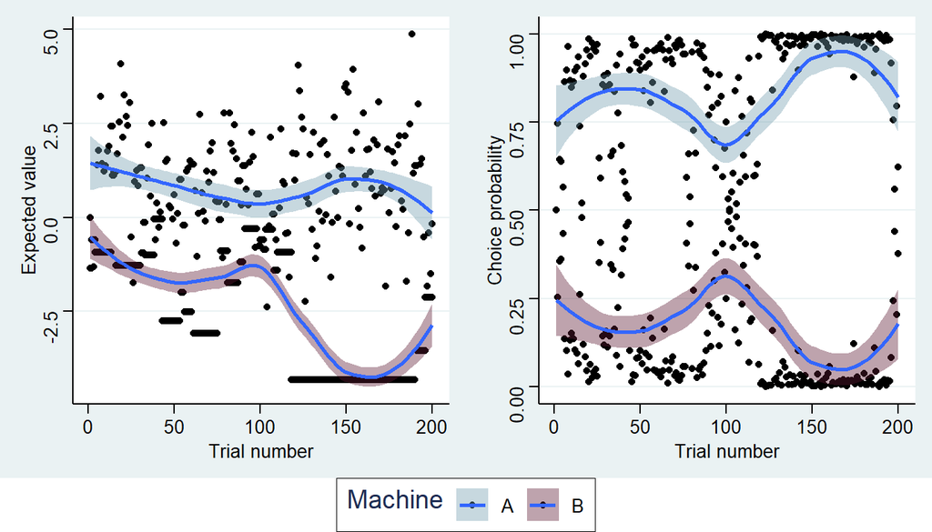

```r
# Visualize individual decision-making behavior across trials
plot_twochoiceRL(data_for_plotting, subj = subject, colors = c("#749dae","#5c1a33"))
```

## Part III: Estimation

You are now ready to implement the estimation techniques to try to see how close you can get to recovering the `alpha` and `beta` values.

```r
# Run maximum-likelihood estimation
mle <- estimate_twochoiceRL(data, method = "mle", plot = FALSE)
```

```r
# Run maximum a posteriori
map <- estimate_twochoiceRL(data, method = "map", plot = FALSE)
```

```r
# Run expectation-maximization with laplace approximation
eml <- estimate_twochoiceRL(data, method = "eml", plot = FALSE)
```

## Summary

Here is a summary of the performances of all three estimation techniques in recovering the **true** parameter values:

```r
# NOTE: Please refer to Suthaharan et al., 2021 for reasons to re-parameterizing

# 'true' parameter values
alpha <- 1/(1+exp(-data$x2[[subject]]))
beta <- exp(data$x1[[subject]])

# alpha range: 0 <= alpha <= 1; lower values => slow learning, higher values => fast learning
# beta range: beta >= 0; lower values => exploration, higher values => exploitation

# MLE parameter values
alpha_mle <- 1/(1+exp(-mle$value$x2.hat[[subject]]))
beta_mle <- exp(mle$value$x1.hat[[subject]])

# MAP parameter values
alpha_map <- 1/(1+exp(-map$value$x2.hat[[subject]]))
beta_map <- exp(map$value$x1.hat[[subject]])

# EML parameter values
alpha_eml <- 1/(1+exp(-eml$value$x2.hat[[subject]]))
beta_eml <- exp(eml$value$x1.hat[[subject]])

# summarize in data frame
summary <- data.frame(True = c(alpha, beta),
                      MLE = c(alpha_mle, beta_mle),
                      MAP = c(alpha_map, beta_map),
                      EML = c(alpha_eml, beta_eml)
                      )

# print table
library(dplyr)
row.names(summary) <- c("$\\alpha$", "$\\beta$")
knitr::kable(summary,
             format = "html",
             align = "c",
             digits = 3,
             table.attr = "style='width:20%;'") %>%
  kableExtra::kable_styling(font_size = 20)
```

|  | True | MLE | MAP | EML |
| --- | --- | --- | --- | --- |
| $\alpha$ | 0.605 | 0.747 | 0.744 | 0.662 |
| $\beta$ | 0.797 | 0.671 | 0.673 | 0.724 |

To summarize, you just implemented three estimation techniques to recover behavior from simulated individual 47. All techniques did fairly well in recovering the *true* parameter values. However, the EML technique performed better.

You have now validated parameter estimation using simulated behavior.

In reality, you will not have *true* parameter values to compare your estimates with, but this validation gives you confidence that estimating on real behavior will extract reliable parameter estimates.

You proceed to recruit 100 real individuals to participate in your task and estimate their behavior.

## Take Home Message

- Simulations provide a great way to validate parameter estimation techniques.
- Parameter estimation is crucial for modeling complex systems, like human behavior.